# Exemple de DiD

# Les différences de différences

Le code contenu dans ce document a servi à créer les graphes utilisées dans la première conférence.

```r
## Bibliothèques utilisées dans la suite du code
library(ggplot2)
library(dplyr)

## La génération de nombres pseudo aléatoires dépend d'une "seed". En la fixant
## à un nombre donné, on s'assure que les nombres pseudo aléatoires tirés sont
## à chaque fois les mêmes et donc que l'on obtient le même résultat.
set.seed(0)
```

## Génération des données

On commence par créer un tableau avec 5 périodes (de 0 à 4) et deux États, A et B.

```r
periods = 0:4
states  = c('A', 'B')
data = expand.grid(period=periods, state=states)
```

Ce tableau ressemble à ça :

```r
data
```

```
##    period state
## 1       0     A
## 2       1     A
## 3       2     A
## 4       3     A
## 5       4     A
## 6       0     B
## 7       1     B
## 8       2     B
## 9       3     B
## 10      4     B
```

```r
data = data %>%
  group_by(period) %>%
  mutate(
    time_fixed_effect = runif(n=1, 1,7)
  )
```

Le tableau ressemble désormais à ça :

```r
data
```

```
## # A tibble: 10 x 3
## # Groups:   period [5]
##    period state time_fixed_effect
##     <int> <fct>             <dbl>
##  1      0 A                  6.38
##  2      1 A                  2.59
##  3      2 A                  3.23
##  4      3 A                  4.44
##  5      4 A                  6.45
##  6      0 B                  6.38
##  7      1 B                  2.59
##  8      2 B                  3.23
##  9      3 B                  4.44
## 10      4 B                  6.45
```

On note que la valeur de `time_fixed_effect`est la même pour une période donnée dans les deux États.

```r
data = data %>%
  group_by(state) %>%
  mutate(
    state_fixed_effect = runif(n=1, 3,10)
  )

data
```

```
## # A tibble: 10 x 4
## # Groups:   state [2]
##    period state time_fixed_effect state_fixed_effect
##     <int> <fct>             <dbl>              <dbl>
##  1      0 A                  6.38               4.41
##  2      1 A                  2.59               4.41
##  3      2 A                  3.23               4.41
##  4      3 A                  4.44               4.41
##  5      4 A                  6.45               4.41
##  6      0 B                  6.38               9.29
##  7      1 B                  2.59               9.29
##  8      2 B                  3.23               9.29
##  9      3 B                  4.44               9.29
## 10      4 B                  6.45               9.29
```

On note que la valeur de `state_fixed_effect`est la même pour un État donné dans toutes les périodes.

On simule maintenant le traitement en prenant le cas où l’État *A* est traité en période *3*, et où le traitement a pour effet *+1.5*.

```r
data = data %>%
  ungroup() %>%
  mutate(
    treated = state == 'A' & period >= 3,
    treatment_effect = treated * 1.5,
    Y = time_fixed_effect + state_fixed_effect + treatment_effect,
    Y_without_treatment = time_fixed_effect + state_fixed_effect
  ) %>%
  select(-treated)
```

Finalement, on a obtenu le tableau suivant :

```r
data
```

```
## # A tibble: 10 x 7
##    period state time_fixed_effect state_fixed_effe… treatment_effect     Y
##     <int> <fct>             <dbl>             <dbl>            <dbl> <dbl>
##  1      0 A                  6.38              4.41              0   10.8
##  2      1 A                  2.59              4.41              0    7.00
##  3      2 A                  3.23              4.41              0    7.64
##  4      3 A                  4.44              4.41              1.5 10.3
##  5      4 A                  6.45              4.41              1.5 12.4
##  6      0 B                  6.38              9.29              0   15.7
##  7      1 B                  2.59              9.29              0   11.9
##  8      2 B                  3.23              9.29              0   12.5
##  9      3 B                  4.44              9.29              0   13.7
## 10      4 B                  6.45              9.29              0   15.7
## # ... with 1 more variable: Y_without_treatment <dbl>
```

## Graphes

### Ce qui est observé

On crée un graphe à partir du tableau `data`, où :

- l’axe des x représente la variable `period`
- l’axe des y représente la variable `Y`
- la couleur des lignes représente la variable `state`
- et l’on trace une ligne par `state`

```r
graphe_base = ggplot(
  data,
  aes(
    x = period,
    y = Y,
    group = state,
    color = state
    )
  ) +
  geom_line(size=1) +
  theme_minimal() +
  scale_y_continuous(limits=c(0,20)) +
  geom_vline(xintercept=2, linetype=3) +
  theme(legend.position="none")

graphe_observe = graphe_base +
  labs(
    x='Périodes',
    y="Variable d'intérêt",
    title="Différence de différence : ce qu'on observe")
```

On peut visualiser le graphe :

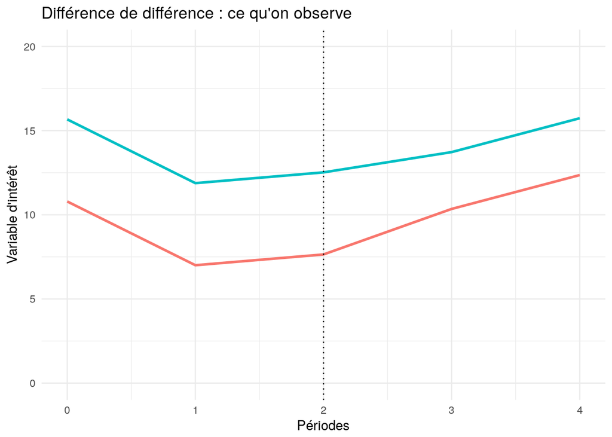

```r
graphe_observe
```

### Le cas idéal

On crée un second graphe qui représente le cas idéal : celui où l’on peut observer la valeur de *Y* si le traitement n’avait pas eu lieu. Pour cela, on ajoute un second jeu de lignes où l’axe des *y* représente la valeur de *Y* sans traitement.

- Pour l’État B, les lignes *Y* et *Y* sans traitement sont superposées
- Pour l’État A, les lignes *Y* et *Y* sans traitement ne sont pas superposées, et la différence entre les deux est l’effet du traitement, représenté par le segment noir

```r
## Fonction qui à une période p et un État s associe la valeur de la variable var
## dans l'État s en période p
get = function(p,s, var) {(data %>% filter(period == p, state == s)) %>% select(var)}

real_value_A_3 = get(3, 'A', "Y")
counterfactual_value_A_3 = real_value_A_3 -  get(3, 'A', "treatment_effect")

graphe_contrefactuel = graphe_base + ## on prend le graphe initial
  geom_line(
    aes(y=Y_without_treatment), ## on y ajoute une ligne où l'axe des Y représente
    linetype = 2, size=1        ## la valeur de Y sans traitement
    ) +
  labs(
    x='Périodes',
    y="Variable d'intérêt",
    title="Différence de différence : si le contrefactuel était observable"
  ) +
  geom_segment(
    aes(
      x = 3,                           ## on rajoute un segment allant du point
      y = real_value_A_3,              ## (3, valeur de Y dans l'État A en 3)
      xend = 3,                        ## au point
      yend = counterfactual_value_A_3  ## (3, valeur de Y si il n'y avait pas de
    ),                                 ## traitement, dans l'État A en 3)
    size=0.75,
    colour = "black",
    linetype = 1
    )
```

Ce qui nous donne le graphe suivant :

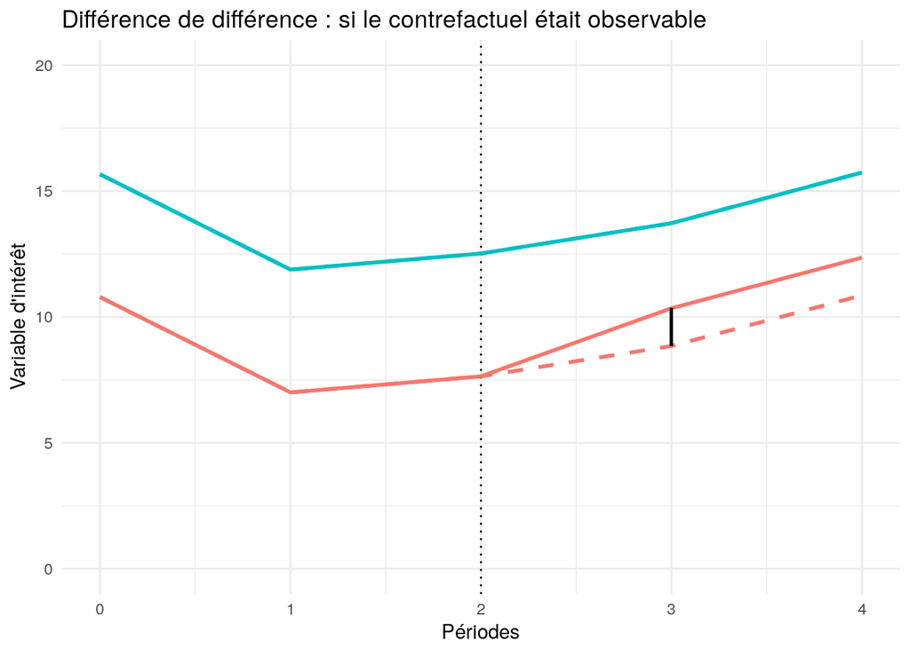

```r
graphe_contrefactuel
```

### Comment estimer l’effet du traitement ?

Revenons à ce que l’on observe :

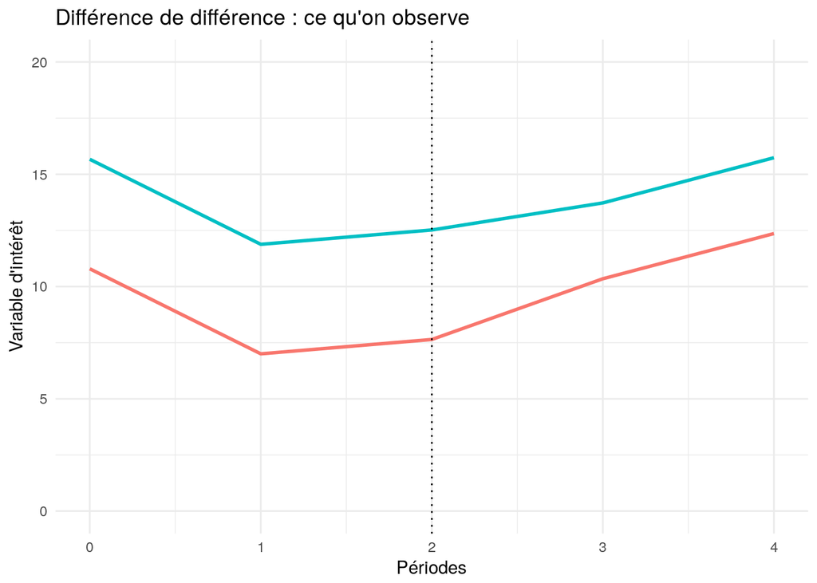

```r
graphe_observe
```

On souhaite calculer la valeur du traitement, à savoir la valeur de *Y* dans l’État A en période 3 (ou après) - la valeur qu’aurait eue *Y* dans l’État A à la même période *si l’État A n’avait pas été traité*.

Comment approximer la valeur de “*Y* si le traitement n’avait pas eu lieu” ?

#### Avant-Après

Une première solution serait de prendre la valeur de Y dans l’État A avant le traitement pour approximer la valeur de “*Y* si le traitement n’avait pas eu lieu”.

C’est à dire que l’effet estimé du traitement serait :

```r
get(3, 'A', 'Y') - get(2, 'A', 'Y')
```

```
##          Y
## 1 2.704377
```

Ce qui n’est pas l’effet réel de 1.5.

Comparer les valeurs de Y avant et après le traitement est égal à la somme de :

- la valeur du traitement
- de la variation entre la période 3 et la période 2 qui n’est pas due au traitement

En faisant ce calcul, on a supposé qu’en l’absence de traitement, *Y* aurait la même valeur dans l’État A en période 2 et 3.

On peut représenter cela graphiquement :

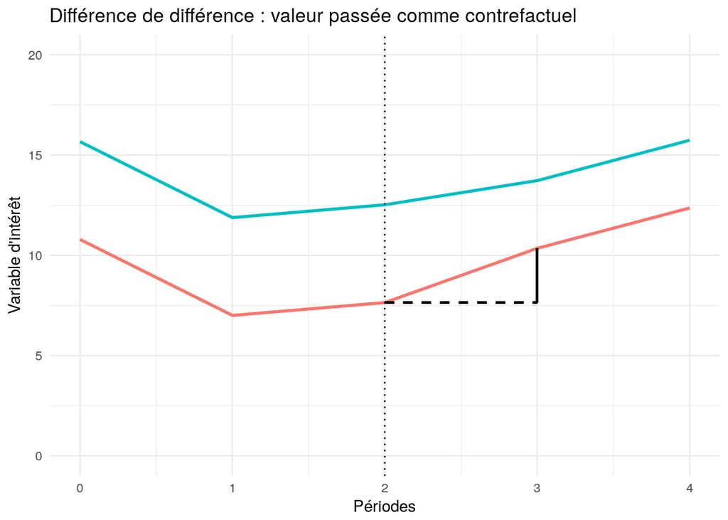

```r
graphe_avant_apres = graphe_base +
  labs(
    x='Périodes',
    y="Variable d'intérêt",
    title="Différence de différence : valeur passée comme contrefactuel"
    ) +
  geom_segment(
    size=0.75,
    aes(x = 2, y = get(2, 'A', 'Y'), xend = 3, yend = get(2, 'A', 'Y')),
    colour = "black",
    linetype = 2
    ) +
  geom_segment(
    size=0.75,
    aes(x = 3, y =  get(3, 'A', 'Y'), xend = 3, yend =get(2, 'A', 'Y')),
    colour = "black",
    linetype = 1
    ) +
  theme_minimal() +
  theme(legend.position="none")

graphe_avant_apres
```

#### Comparaison entre les États

Une deuxième solution serait de prendre la valeur de Y dans l’État B en période 3 pour approximer la valeur de “*Y* si le traitement n’avait pas eu lieu”.

C’est à dire que l’effet estimé du traitement serait :

```r
get(3, 'A', 'Y') - get(3, 'B', 'Y')
```

```
##           Y
## 1 -3.376954
```

Ce qui n’est pas l’effet réel de 1.5.

Comparer les valeurs de Y dans les deux États après le traitement est égal à la somme de :

- la valeur du traitement
- et de la différence permanente entre les États A et B

En faisant ce calcul, on a supposé qu’en l’absence de traitement, Y aurait la même valeur dans l’État A en période 3 et que dans l’État B en période 3.

On peut représenter cela graphiquement :

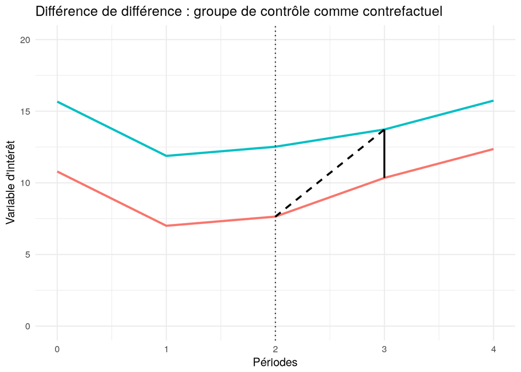

```r
graphe_between_state = graphe_base +
  labs(
    x='Périodes',
    y="Variable d'intérêt",
    title="Différence de différence : groupe de contrôle comme contrefactuel"
    ) +
  geom_segment(
    size=0.75,
    aes(x = 2, y = get(2, 'A', 'Y'), xend = 3, yend = get(3, 'B', 'Y')),
    colour = "black",
    linetype = 2
    ) +
  geom_segment(
    size=0.75,
    aes(x = 3, y =  get(3, 'A', 'Y'), xend = 3, yend =get(3, 'B', 'Y')),
    colour = "black",
    linetype = 1
    ) +
  theme_minimal() +
  theme(legend.position="none")

graphe_between_state
```

### Différence de différences

Revenons au à la comparaison avant-après.

Comparer les valeurs de Y dans l’État A avant et après le traitement est égal à la somme de :

- la valeur du traitement
- la variation de Y dans l’État A entre la période 3 et la période 2 qui n’est pas due au traitement

Si l’on fait la même comparaison avant-après dans l’État B (non traité), on obtient la somme de :

- la valeur du traitement dans l’État B qui est 0, puisque l’État n’est pas traité
- et de la variation de Y dans l’État B entre la période 3 et la période 2 qui n’est pas due au traitement

Si l’on suppose que la variation entre les période 2 et 3 est la même dans les deux États (ce qui est le cas dans notre expemple puisque c’est comme cela que l’on a construit nos données) on peut faire la différence des deux différences avant après, ce qui donne (traitement + variation entre 2 et 3) - (0 + variation entre 2 et 3) = traitement.

On suppose donc que la valeur contrefactuelle de Y en période 3 dans l’État A serait la somme de :

- la valeur de Y en période 2 dans l’État A
- la différence entre la valeur de Y en période 3 et en période 2 dans l’État B (par hypothèse, égale en A et en B)

```r
contrefactuel_A_3 = get(2, 'A', 'Y') + (get('3', 'B', 'Y') - get('2', 'B', 'Y'))
```

Représentons le graphiquement :

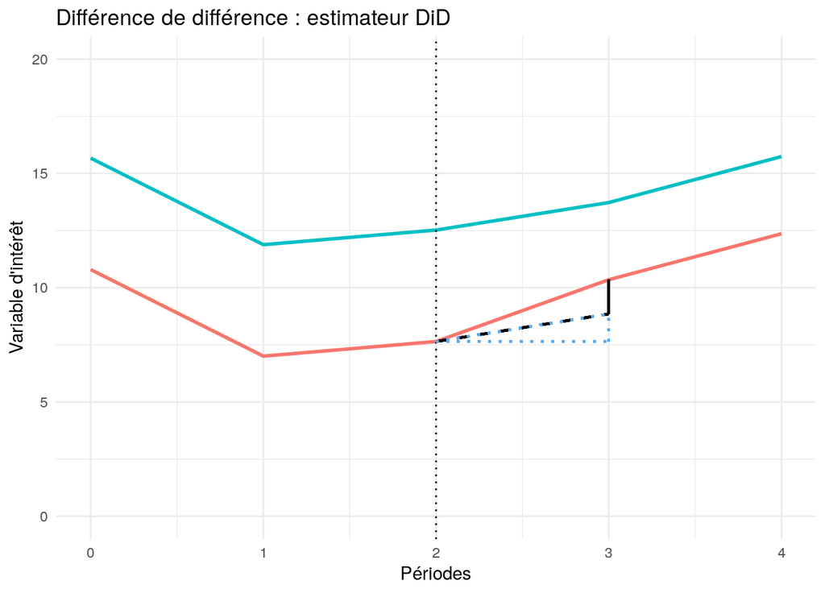

```r
graphe_did = graphe_base +
  labs(
    x='Périodes',
    y="Variable d'intérêt",
    title="Différence de différence : estimateur DiD"
    ) +
  theme_minimal() +
  theme(legend.position="none") +
  geom_segment(
    size=0.75,
    aes(x = 2, y = get(2, 'A', 'Y'), xend = 3, yend = contrefactuel_A_3),
    colour = "black",
    linetype = 2
    ) +
  geom_segment(
    size=0.75,
    aes(x = 3, y = get(3, 'A', 'Y'), xend = 3, yend = contrefactuel_A_3),
    colour = "black",
    linetype = 1
    ) +
  geom_segment(
    size=0.75,
    aes(x = 2, y = get(2, 'A', 'Y'), xend = 3, yend = get(2, 'A', 'Y')),
    colour = "steelblue2",
    linetype = 3
    ) +
  geom_segment(
    size=0.75,
    aes(x = 3, y = get(2, 'A', 'Y'), xend = 3, yend = contrefactuel_A_3),
    colour = "steelblue2",
    linetype = 3
    ) +
    geom_segment(
    size=0.75,
    aes(x = 2, y = get(2, 'A', 'Y'), xend = 3, yend = contrefactuel_A_3),
    colour = "steelblue2",
    linetype = 3
    )

graphe_did
```

Le triangle bleu représente l’évolution supposée de Y en l’absence de traitement dans l’État B, qui nous permet de déduire le triangle noir, l’effet estimé du traitement.

Parce que nous avons supposé en créant nos données que les évolutions au cours du temps étaient les mêmes dans les deux États, notre valeur estimée du contrefactuel (et donc de l’effet du traitement) correspond bien à la valeur réelle :

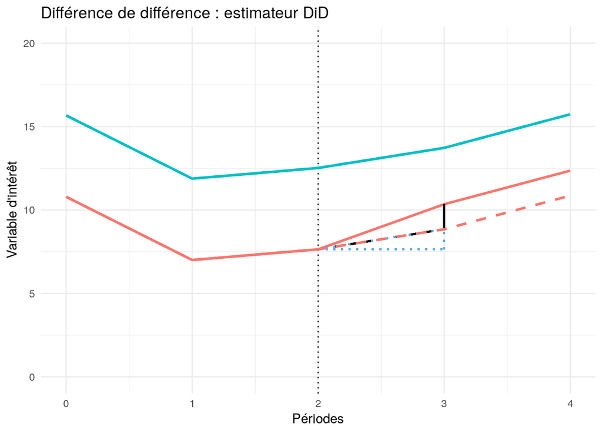

```r
graphe_did + geom_line(size=1, aes(y=Y_without_treatment), linetype = 2)
```

L’effet estimé est :

```r
contrefactuel_A_3 = get(2, 'A', 'Y') + (get('3', 'B', 'Y') - get('2', 'B', 'Y'))
valeur_reelle_A_3 = get(3, 'A', 'Y')
effet_estime = valeur_reelle_A_3 - contrefactuel_A_3

effet_estime
```

```
##     Y
## 1 1.5
```

C’est à dire la valeur réelle du traitement.

### Quand l’hypothèse des tendances parallèles n’est pas vérifiée

Créons un cas où cette hypothèse des tendances parallèles n’est pas vérifiée, en modifiant les données initiales :

```r
data = data %>% ## notez que l'on ne groupe plus par period !
  mutate(
    time_fixed_effect = runif(n=n(), 2,7)
  )

data
```

```
## # A tibble: 10 x 7
##    period state time_fixed_effect state_fixed_effe… treatment_effect     Y
##     <int> <fct>             <dbl>             <dbl>            <dbl> <dbl>
##  1      0 A                  6.72              4.41              0   10.8
##  2      1 A                  5.30              4.41              0    7.00
##  3      2 A                  5.15              4.41              0    7.64
##  4      3 A                  2.31              4.41              1.5 10.3
##  5      4 A                  3.03              4.41              1.5 12.4
##  6      0 B                  2.88              9.29              0   15.7
##  7      1 B                  5.44              9.29              0   11.9
##  8      2 B                  3.92              9.29              0   12.5
##  9      3 B                  5.85              9.29              0   13.7
## 10      4 B                  4.49              9.29              0   15.7
## # ... with 1 more variable: Y_without_treatment <dbl>
```

On refait nos calculs et notre graphe :

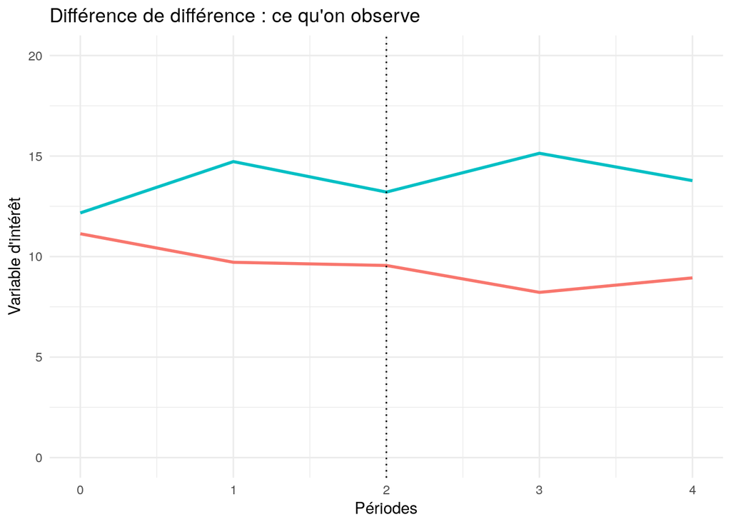

```r
data = data %>%
  mutate(
    Y = time_fixed_effect + state_fixed_effect + treatment_effect,
    Y_without_treatment = time_fixed_effect + state_fixed_effect
  )

graphe_base = ggplot(
  data,
  aes(
    x = period,
    y = Y,
    group = state,
    color = state
    )
  ) +
  geom_line(size=1) +
  theme_minimal() +
  scale_y_continuous(limits=c(0,20)) +
  geom_vline(xintercept=2, linetype=3) +
  theme(legend.position="none")

graphe_0 = graphe_base +
  labs(
    x='Périodes',
    y="Variable d'intérêt",
    title="Différence de différence : ce qu'on observe")

graphe_0
```

Les tendances ne sont plus parallèles. On peut tout de même calculer un contrefactuel de la même manière que précedemment :

```r
contrefactuel_A_3 = get(2, 'A', 'Y') + (get('3', 'B', 'Y') - get('2', 'B', 'Y'))
```

Et en déduire une estimation de l’effet du traitement :

```r
valeur_reelle_A_3 = get(3, 'A', 'Y')
effet_estime = valeur_reelle_A_3 - contrefactuel_A_3

effet_estime
```

```
##           Y
## 1 -3.265327
```

Qui est très éloignée de l’effet réel, *+1.5*.

Représentons notre estimation graphiquement :

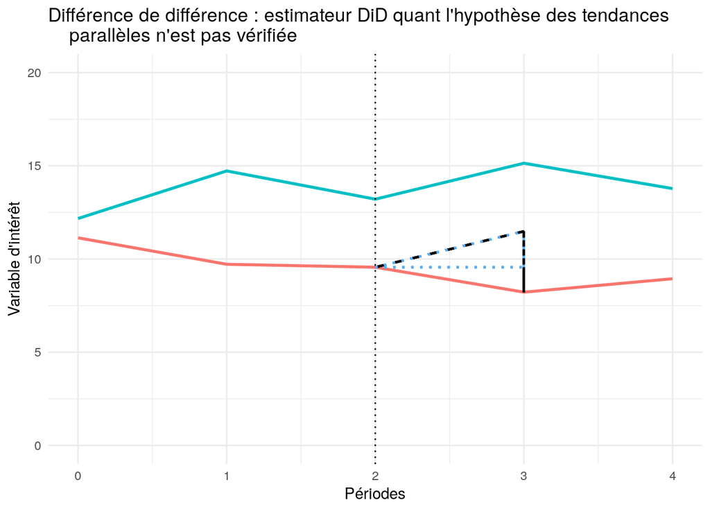

```r
graphe_did = graphe_base +
  labs(
    x='Périodes',
    y="Variable d'intérêt",
    title="Différence de différence : estimateur DiD quant l'hypothèse des tendances
    parallèles n'est pas vérifiée"
    ) +
  theme_minimal() +
  theme(legend.position="none") +
  geom_segment(
    size=0.75,
    aes(x = 2, y = get(2, 'A', 'Y'), xend = 3, yend = contrefactuel_A_3),
    colour = "black",
    linetype = 2
    ) +
  geom_segment(
    size=0.75,
    aes(x = 3, y = get(3, 'A', 'Y'), xend = 3, yend = contrefactuel_A_3),
    colour = "black",
    linetype = 1
    ) +
  geom_segment(
    size=0.75,
    aes(x = 2, y = get(2, 'A', 'Y'), xend = 3, yend = get(2, 'A', 'Y')),
    colour = "steelblue2",
    linetype = 3
    ) +
  geom_segment(
    size=0.75,
    aes(x = 3, y = get(2, 'A', 'Y'), xend = 3, yend = contrefactuel_A_3),
    colour = "steelblue2",
    linetype = 3
    ) +
    geom_segment(
    size=0.75,
    aes(x = 2, y = get(2, 'A', 'Y'), xend = 3, yend = contrefactuel_A_3),
    colour = "steelblue2",
    linetype = 3
    )

graphe_did
```

Notre calcul n’a plus rien à voir avec l’effet réel :

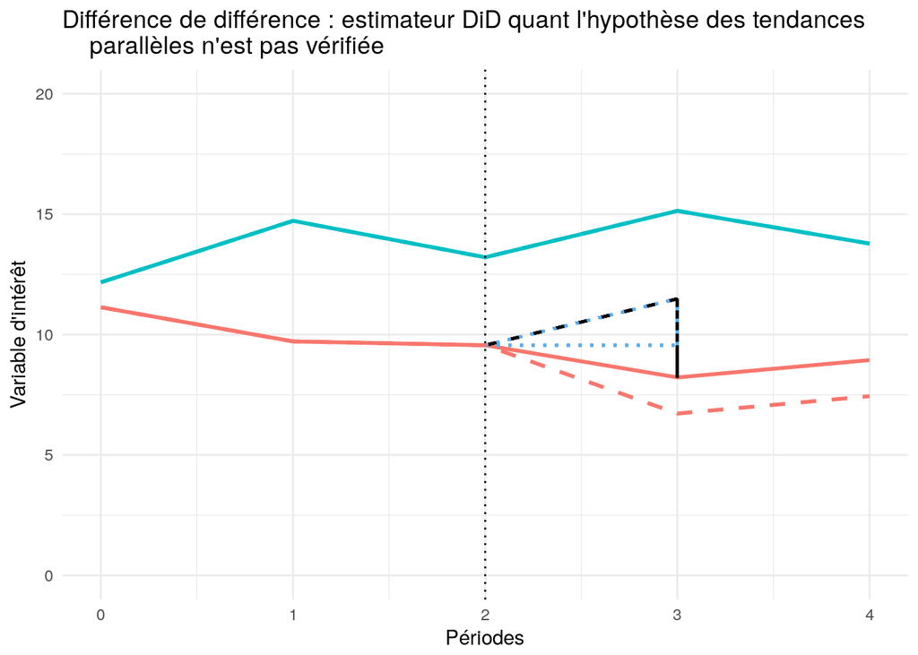

```r
graphe_did + geom_line(size=1, aes(y=Y_without_treatment), linetype = 2)
```